# Logboek: Publieke Opinie

# Circulair Packing test 1:

Test met data van het internet om het hierachrische data format beter te begrijpen.

```r
# Load dataset from github
data <- read.table("https://raw.githubusercontent.com/holtzy/data_to_viz/master/Example_dataset/11_SevCatOneNumNestedOneObsPerGroup.csv", header=T, sep=";")
data[ which(data$value==-1),"value"] <- 1
colnames(data) <- c("Continent", "Region", "Country", "Pop")

# Remove a few problematic lines
data <- data %>% filter(Continent!="") %>% droplevels()

# Change the format. This use the data.tree library. This library needs a column that looks like root/group/subgroup/..., so I build it
library(data.tree)
data$pathString <- paste("world", data$Continent, data$Region, data$Country, sep = "/")
population <- as.Node(data)
data <- data.frame(
  root=rep("root", 15),
  group=c(rep("group A",5), rep("group B",5), rep("group C",5)),
  subgroup= rep(letters[1:5], each=3),
  subsubgroup=rep(letters[1:3], 5),
  value=sample(seq(1:15), 15)
)


# root = hele populatie
# group = geslacht
# subgroup = profintie
# value = de waarde van het punt wat we willen visualizeren.


# Change the format. This use the data.tree library. This library needs a column that looks like root/group/subgroup/..., so I build it

data$pathString <- paste("world", data$group, data$subgroup, data$subsubgroup, sep = "/")
population <- as.Node(data)
population



#graph <- tbl_graph(flare$vertices, flare$edges)
set.seed(1)
ggraph(graph, 'circlepack', weight = size) +
  geom_node_circle(aes(fill = depth), size = 0.25, n = 50) +
  coord_fixed()
```

[output not shown]

15-05-2024: Om te achterhalen of de leeftijden van de mensen die de enquete ingevuld hebben normaal verdeeld zijn is de Shapiro Wilk test gebruikt.

### Shapiro Wilk test:

Deze test wordt uitgevoerd om vast te stellen of leeftijden van de mensen die de enquete ingevuld hebben normaal verdeeld is.

```r
shapiro_test <- shapiro.test(abortus$Wat.is.uw.leeftijd.)
shapiro_test
```

```
##
##  Shapiro-Wilk normality test
##
## data:  abortus$Wat.is.uw.leeftijd.
## W = 0.9254, p-value = 1.261e-05
```

# Power analyse:

```r
#pwr.t.test(n = n, d = d, sig.level = alpha, type = "one.sample", alternative = "less")
```

### Pie chart:

Niet gebruiken, alleen om te proberen…

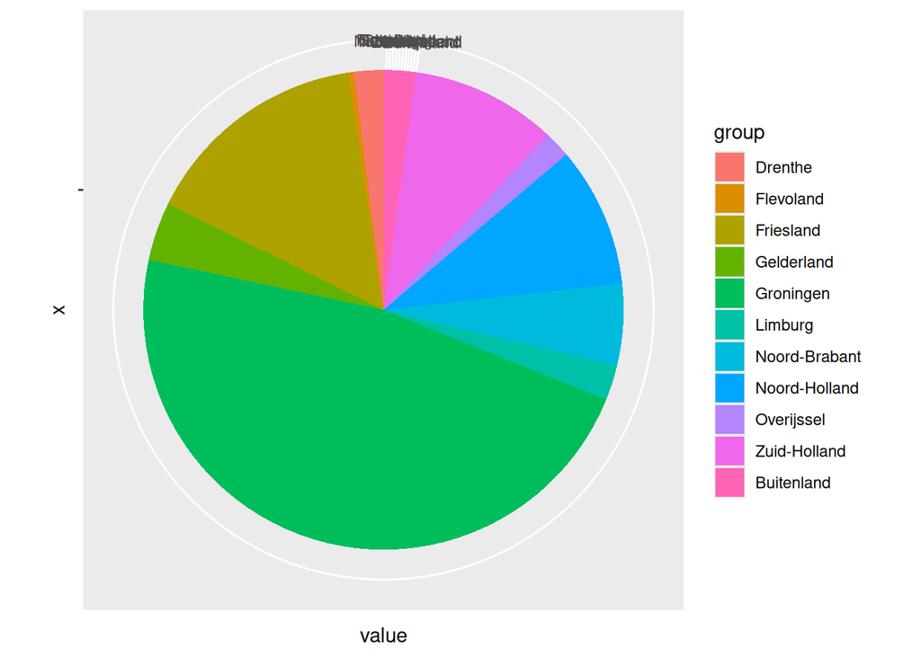

```r
# Create Data
data <- data.frame(
  group=abortus$afkomst,
  value=abortus$afkomst
)

# Basic piechart
ggplot(data, aes(x="", y=value, fill=group)) +
  geom_bar(stat="identity", width=1) +
  coord_polar("y", start=0)
```

```r
proportie_man_vader <- df %>% select(vader) %>% filter(df$geslacht == "Man")
proportie_man_vader_01 <- ifelse(proportie_man_vader == "Ja" , 0,1)

hi <- prop.table(proportie_man_vader_01)

proportie_vrouw_vader <-

ggplot(df, aes( y = vader)) +
  geom_bar(aes()) +
  labs(color = "test") +
  #scale_color_manual(name = "Cylinders")
#  scale_fill_discrete(name = "test") +
  ggtitle("Moet de vader zeggenschap hebben over \nde beslissing om een abortus te induceren? ")
```

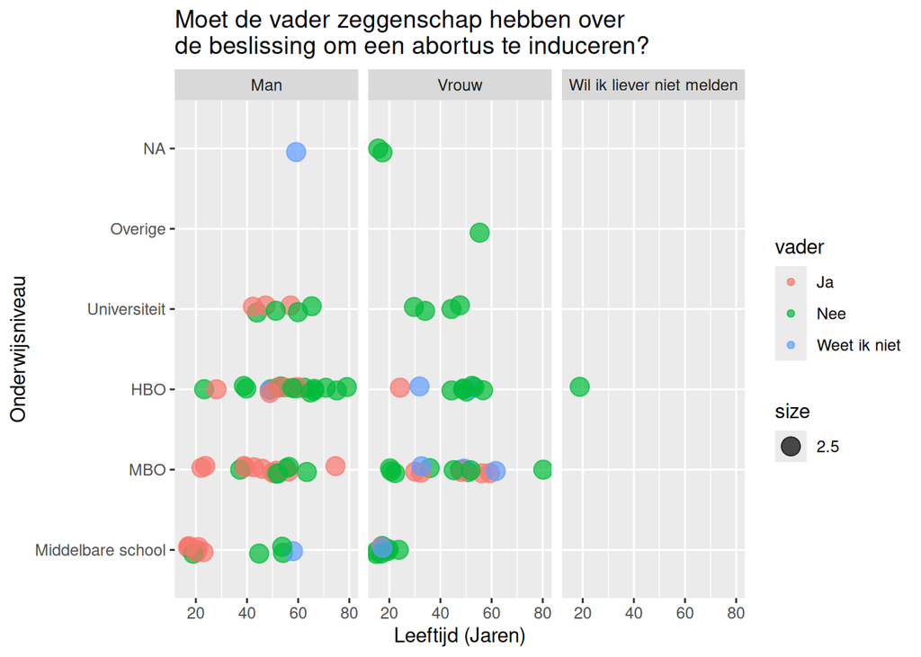

```r
ggplot(df, aes(x= Wat.is.uw.leeftijd., y = onderwijsniveau)) +
 # geom_point(aes(color = vader, size = 2.5), alpha = 0.5) +
  facet_wrap(~geslacht) +
  labs(" ") +
  xlab("Leeftijd (Jaren)") +
  ylab("Onderwijsniveau") +
  geom_jitter(aes(color = vader, size = 2.5), alpha = 0.7, height = 0.05) +
  ggtitle("Moet de vader zeggenschap hebben over \nde beslissing om een abortus te induceren?")
```

20-05-2024:

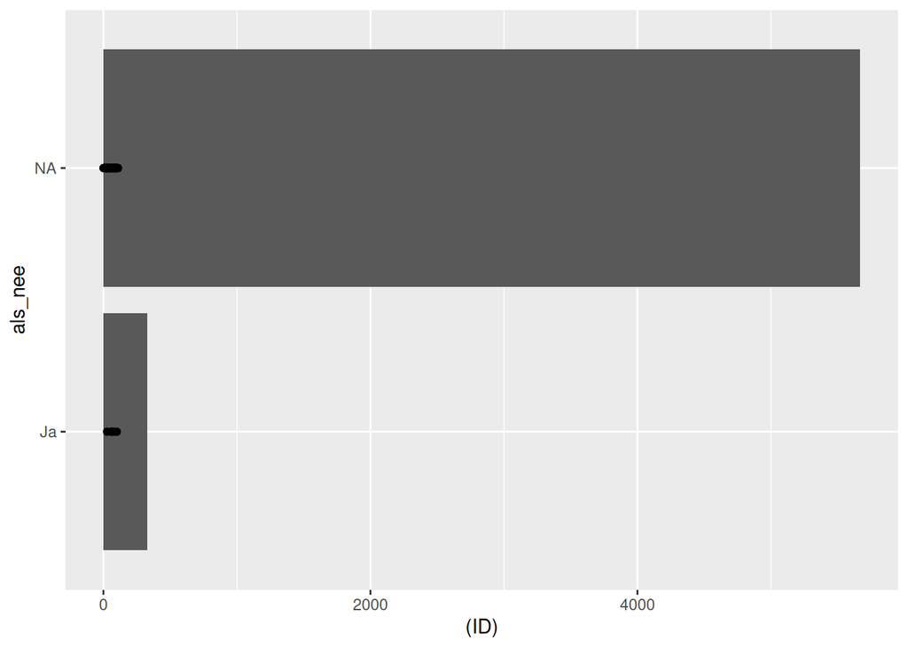

```r
# Voor vraag: Als u geen voorstander bent voor de vrijheid om voor een abortus te kiezen, zijn er gevallen waarin dit wel zou mogen?

ggplot(data = df, mapping = aes(x = (ID), y = als_nee)) +
  geom_bar(stat = "identity") +
  geom_point()
```

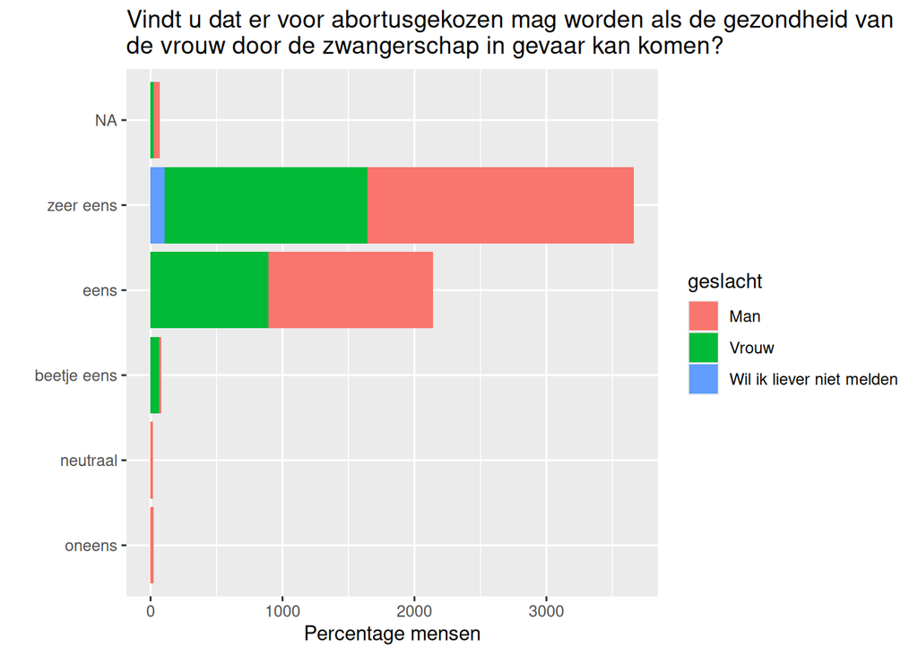

```r
# Voor de vraag: Vindt u dat er voor abortusgekozen mag worden als de gezondheid van de vrouw door de zwangerschap in gevaar kan komen?
library(ggridges)
ggplot(data = df, mapping = aes(x = c(1:109), y = levensgevaar_vrouw_o, fill = geslacht)) +
  geom_bar(stat = "identity") +
  geom_text(aes(label = (" "))) +
  ggtitle("Vindt u dat er voor abortusgekozen mag worden als de gezondheid van \nde vrouw door de zwangerschap in gevaar kan komen?") +
  xlab("Percentage mensen") + # nog aapassen naar procent.
  ylab(" ") # Geen ylabel nodig omdat er al een beschrijving bij de waardes staan.
```

```r
  # labels beter maken.
  # To-do: prercentage verbeteren, huidige waarden kloppen nog niet.
```

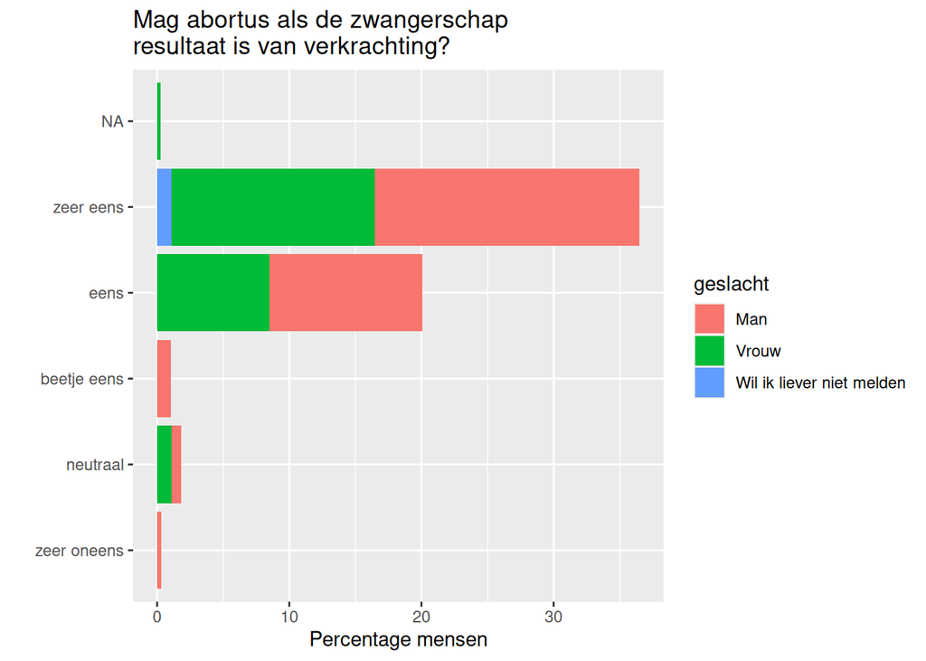

```r
# Voor de vraag: Mag abortus toegestaan zijn als de zwangerschap resultaat is van verkrachting?

ggplot(data = df, mapping = aes(x = (ID/100), y = veroorzaakt_o, fill = geslacht)) + # geeft procent weer.
  geom_bar(stat = "identity") +
  ggtitle("Mag abortus als de zwangerschap\nresultaat is van verkrachting?") +
  xlab("Percentage mensen") + # verifiëren of dit wel klopt...
  ylab(" ")
```

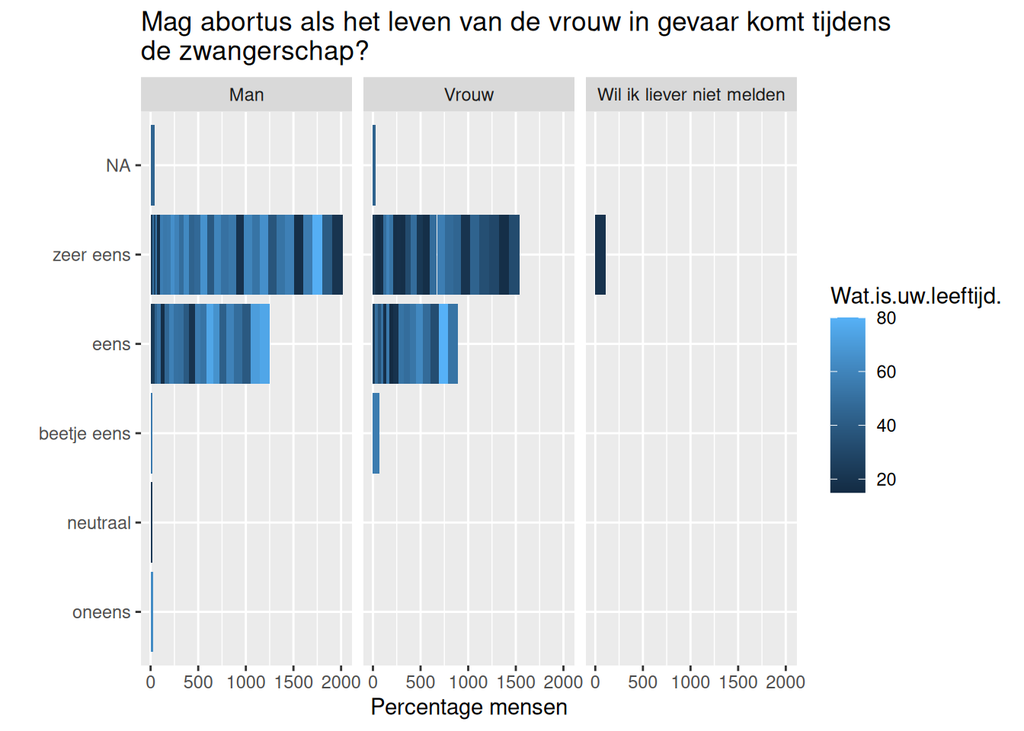

```r
#Voor de vraag:
#ggplot(data = df, mapping = aes(x = ))


ggplot(data = df, mapping = aes(x = (c(1:109)), y = levensgevaar_vrouw_o)) + # geeft procent weer.
  geom_bar(stat = "identity", aes(fill = Wat.is.uw.leeftijd.)) +
  facet_wrap(~geslacht) +
  ggtitle("Mag abortus als het leven van de vrouw in gevaar komt tijdens\nde zwangerschap?") +
  xlab("Percentage mensen") + # verifiëren of dit wel klopt...
  ylab(" ")
```

```r
  # To-do: sorteer voorl leeftijd gradient.
```

25-05-2024: # Donut grafiek: Op de onderstaande grafieken wordt het aantal mensen per provincie gevisualiseerd.

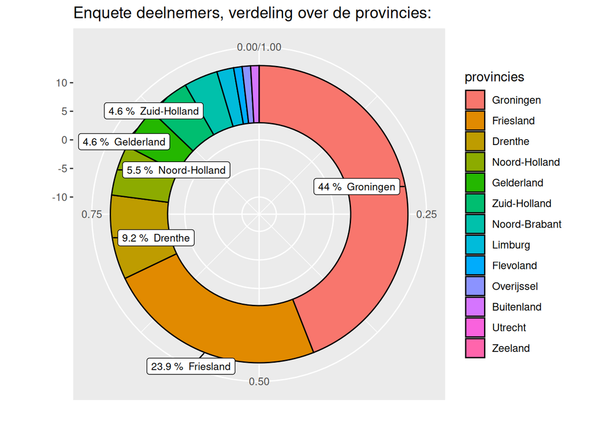

```r
#library(ggrepel)

# Maak tabel met aantal mensen per provincie.
x <- table(abortus$afkomst)
x <- sort(x, decreasing = T)
provincie_aantal <- data.frame(x)


# Reken de percentages uit:
provincie_aantal$fraction = provincie_aantal$Freq / sum(provincie_aantal$Freq)
provincie_aantal$percentage = round(provincie_aantal$fraction *100, digits =1)
provincie_aantal$ymax = cumsum(provincie_aantal$fraction)
provincie_aantal$ymin = c(0, head(provincie_aantal$ymax, n=-1))
provincie_aantal$labelp = (provincie_aantal$ymax+provincie_aantal$ymin)/2
provincie_aantal$label = (paste(provincie_aantal$percentage, "% ", provincie_aantal$Var1))

# Verander de naam van de provincie colom van Var1 naar "provincies":
provincie_aantal <- provincie_aantal %>%
    rename(provincies = Var1)


# Maak het grafiekje:
ggplot(provincie_aantal,aes(ymax=ymax, ymin=ymin, xmax=13, xmin=3)) +
     geom_rect(color = "black",aes(fill=provincies)) +
     geom_label_repel(x = 13, aes(y=labelp, label= label), size=3, max.overlaps = 11, min.segment.length = 0) +
    # geom_label( x = 13, aes(y=labelp, label= label), size=4)+
     ggtitle("Enquete deelnemers, verdeling over de provincies:")  +
     coord_polar(theta="y") +
     xlim(c(-13, 13)) +
     xlab(" ") +
     ylab(" ")
```

### Tweede variant (stacked-barchart)

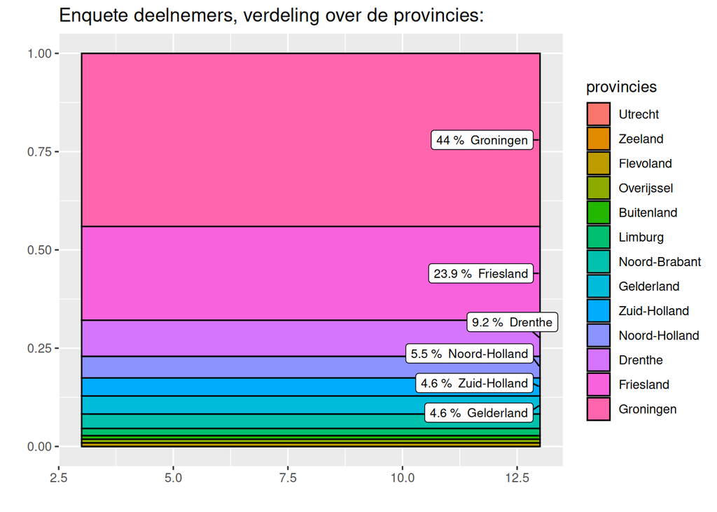

```r
#library(ggrepel)

# Maak tabel met aantal mensen per provincie.
x <- table(abortus$afkomst)
x <- sort(x, decreasing = F)

provincie_aantal <- data.frame(x)

# Reken de percentages uit:
provincie_aantal$fraction = provincie_aantal$Freq / sum(provincie_aantal$Freq)
provincie_aantal$percentage = round(provincie_aantal$fraction *100, digits =1)
provincie_aantal$ymax = cumsum(provincie_aantal$fraction)
provincie_aantal$ymin = c(0, head(provincie_aantal$ymax, n=-1))
provincie_aantal$labelp = (provincie_aantal$ymax+provincie_aantal$ymin)/2
provincie_aantal$label = (paste(provincie_aantal$percentage, "% ", provincie_aantal$Var1))

# Verander de naam van de provincie colom van Var1 naar "provincies":
renamed_provincie_aantal <- provincie_aantal %>%
    rename(provincies = Var1)

# Maak het grafiekje:
ggplot(renamed_provincie_aantal, aes(ymax=ymax, ymin=ymin, xmax=13, xmin=3)) +
     geom_rect(color = "black",aes(fill=provincies)) +
     geom_label_repel(x = 13, aes(y=labelp, label= label), size=3, max.overlaps = 10, min.segment.length = 0) +
    # geom_label( x = 13, aes(y=labelp, label= label), size=4)+
     ggtitle("Enquete deelnemers, verdeling over de provincies:") +
     xlab(" ") +
     ylab(" ")
```